# Final Project Wine Summary Statistics

Jessie Pao

```r
getwd()
```

```
[1] "/Users/jessiepao/Desktop/MGSC 310 - Statisctical Models in Business/MGSC-310-Wine-Final-Project"
```

```r
# load all your libraries in this chunk
library(tidyverse)
library(Hmisc)
library('photobiology')
library(janeaustenr)
library(dplyr)
library(stringr)
library(tidytext)
library(wordcloud)
library(reshape2)
library('randomForest')
library(reshape2)
library(partykit)
library(PerformanceAnalytics)
library(rpart)
library(rpart.plot)
library('randomForestExplainer')
```

Load in wine data set

```r
wine_DF <-
  read.csv(here::here("dataset",
           "wine.csv"))

wine_DF
```

| fixed.acidity | volatile.acidity | citric.acid | residual.sugar | chlorides | free.sulfur.dioxide | total.sulfur.dioxide | density | pH | sulphates | alcohol | quality |
| --- | --- | --- | --- | --- | --- | --- | --- | --- | --- | --- | --- |
| 7.4 | 0.700 | 0.00 | 1.90 | 0.076 | 11.0 | 34 | 0.99780 | 3.51 | 0.56 | 9.4 | 5 |
| 7.8 | 0.880 | 0.00 | 2.60 | 0.098 | 25.0 | 67 | 0.99680 | 3.20 | 0.68 | 9.8 | 5 |
| 7.8 | 0.760 | 0.04 | 2.30 | 0.092 | 15.0 | 54 | 0.99700 | 3.26 | 0.65 | 9.8 | 5 |
| 11.2 | 0.280 | 0.56 | 1.90 | 0.075 | 17.0 | 60 | 0.99800 | 3.16 | 0.58 | 9.8 | 6 |
| 7.4 | 0.700 | 0.00 | 1.90 | 0.076 | 11.0 | 34 | 0.99780 | 3.51 | 0.56 | 9.4 | 5 |
| 7.4 | 0.660 | 0.00 | 1.80 | 0.075 | 13.0 | 40 | 0.99780 | 3.51 | 0.56 | 9.4 | 5 |
| 7.9 | 0.600 | 0.06 | 1.60 | 0.069 | 15.0 | 59 | 0.99640 | 3.30 | 0.46 | 9.4 | 5 |
| 7.3 | 0.650 | 0.00 | 1.20 | 0.065 | 15.0 | 21 | 0.99460 | 3.39 | 0.47 | 10.0 | 7 |
| 7.8 | 0.580 | 0.02 | 2.00 | 0.073 | 9.0 | 18 | 0.99680 | 3.36 | 0.57 | 9.5 | 7 |
| 7.5 | 0.500 | 0.36 | 6.10 | 0.071 | 17.0 | 102 | 0.99780 | 3.35 | 0.80 | 10.5 | 5 |

[output cut: 990 more lines]

```r
NA
```

```r
wine_clean <- wine_DF %>% na.omit()

wine_clean
```

|  | fixed.acidity | volatile.acidity | citric.acid | residual.sugar | chlorides | free.sulfur.dioxide | total.sulfur.dioxide | density | pH | sulphates | alcohol | quality |
| --- | --- | --- | --- | --- | --- | --- | --- | --- | --- | --- | --- | --- |
| 1 | 7.4 | 0.700 | 0.00 | 1.90 | 0.076 | 11.0 | 34 | 0.99780 | 3.51 | 0.56 | 9.4 | 5 |
| 2 | 7.8 | 0.880 | 0.00 | 2.60 | 0.098 | 25.0 | 67 | 0.99680 | 3.20 | 0.68 | 9.8 | 5 |
| 3 | 7.8 | 0.760 | 0.04 | 2.30 | 0.092 | 15.0 | 54 | 0.99700 | 3.26 | 0.65 | 9.8 | 5 |
| 4 | 11.2 | 0.280 | 0.56 | 1.90 | 0.075 | 17.0 | 60 | 0.99800 | 3.16 | 0.58 | 9.8 | 6 |
| 5 | 7.4 | 0.700 | 0.00 | 1.90 | 0.076 | 11.0 | 34 | 0.99780 | 3.51 | 0.56 | 9.4 | 5 |
| 6 | 7.4 | 0.660 | 0.00 | 1.80 | 0.075 | 13.0 | 40 | 0.99780 | 3.51 | 0.56 | 9.4 | 5 |
| 7 | 7.9 | 0.600 | 0.06 | 1.60 | 0.069 | 15.0 | 59 | 0.99640 | 3.30 | 0.46 | 9.4 | 5 |
| 8 | 7.3 | 0.650 | 0.00 | 1.20 | 0.065 | 15.0 | 21 | 0.99460 | 3.39 | 0.47 | 10.0 | 7 |
| 9 | 7.8 | 0.580 | 0.02 | 2.00 | 0.073 | 9.0 | 18 | 0.99680 | 3.36 | 0.57 | 9.5 | 7 |
| 10 | 7.5 | 0.500 | 0.36 | 6.10 | 0.071 | 17.0 | 102 | 0.99780 | 3.35 | 0.80 | 10.5 | 5 |

[output cut: 990 more lines]

```r
NA
```

Summary of wine data set

```r
summary(wine_clean)
```

```
 fixed.acidity   volatile.acidity  citric.acid    residual.sugar     chlorides
 Min.   : 4.60   Min.   :0.1200   Min.   :0.000   Min.   : 0.900   Min.   :0.01200
 1st Qu.: 7.10   1st Qu.:0.3900   1st Qu.:0.090   1st Qu.: 1.900   1st Qu.:0.07000
 Median : 7.90   Median :0.5200   Median :0.260   Median : 2.200   Median :0.07900
 Mean   : 8.32   Mean   :0.5278   Mean   :0.271   Mean   : 2.539   Mean   :0.08747
 3rd Qu.: 9.20   3rd Qu.:0.6400   3rd Qu.:0.420   3rd Qu.: 2.600   3rd Qu.:0.09000
 Max.   :15.90   Max.   :1.5800   Max.   :1.000   Max.   :15.500   Max.   :0.61100
 free.sulfur.dioxide total.sulfur.dioxide    density             pH          sulphates
 Min.   : 1.00       Min.   :  6.00       Min.   :0.9901   Min.   :2.740   Min.   :0.3300
 1st Qu.: 7.00       1st Qu.: 22.00       1st Qu.:0.9956   1st Qu.:3.210   1st Qu.:0.5500
 Median :14.00       Median : 38.00       Median :0.9968   Median :3.310   Median :0.6200
 Mean   :15.87       Mean   : 46.47       Mean   :0.9967   Mean   :3.311   Mean   :0.6581
 3rd Qu.:21.00       3rd Qu.: 62.00       3rd Qu.:0.9978   3rd Qu.:3.400   3rd Qu.:0.7300
 Max.   :72.00       Max.   :289.00       Max.   :1.0037   Max.   :4.010   Max.   :2.0000
    alcohol         quality
 Min.   : 8.40   Min.   :3.000
 1st Qu.: 9.50   1st Qu.:5.000
 Median :10.20   Median :6.000
 Mean   :10.42   Mean   :5.636
 3rd Qu.:11.10   3rd Qu.:6.000
 Max.   :14.90   Max.   :8.000
```

Correlation Matrix

```r
cor_wine <- round(cor(wine_clean), 2)
head(cor_wine)
```

```
                    fixed.acidity volatile.acidity citric.acid residual.sugar chlorides
fixed.acidity                1.00            -0.26        0.67           0.11      0.09
volatile.acidity            -0.26             1.00       -0.55           0.00      0.06
citric.acid                  0.67            -0.55        1.00           0.14      0.20
residual.sugar               0.11             0.00        0.14           1.00      0.06
chlorides                    0.09             0.06        0.20           0.06      1.00
free.sulfur.dioxide         -0.15            -0.01       -0.06           0.19      0.01
                    free.sulfur.dioxide total.sulfur.dioxide density    pH sulphates alcohol
fixed.acidity                     -0.15                -0.11    0.67 -0.68      0.18   -0.06
volatile.acidity                  -0.01                 0.08    0.02  0.23     -0.26   -0.20
citric.acid                       -0.06                 0.04    0.36 -0.54      0.31    0.11
residual.sugar                     0.19                 0.20    0.36 -0.09      0.01    0.04
chlorides                          0.01                 0.05    0.20 -0.27      0.37   -0.22
free.sulfur.dioxide                1.00                 0.67   -0.02  0.07      0.05   -0.07
                    quality
fixed.acidity          0.12
volatile.acidity      -0.39
citric.acid            0.23
residual.sugar         0.01
chlorides             -0.13
free.sulfur.dioxide   -0.05
```

```r
get_upper_tri <- function(cor_wine){
    cor_wine[lower.tri(cor_wine)]<- NA
    return(cor_wine)
}

reorder_cor_wine <- function(cor_wine){
# Use correlation between variables as distance
dd <- as.dist((1-cor_wine)/2)
hc <- hclust(dd)
cor_wine <-cor_wine[hc$order, hc$order]
}
```

Reshape the correlation matrix

```r
#cor_wine <- reorder_cor_wine(cor_wine)

upper_tri <- get_upper_tri(cor_wine)
upper_tri
```

```
                     fixed.acidity volatile.acidity citric.acid residual.sugar chlorides
fixed.acidity                    1            -0.26        0.67           0.11      0.09
volatile.acidity                NA             1.00       -0.55           0.00      0.06
citric.acid                     NA               NA        1.00           0.14      0.20
residual.sugar                  NA               NA          NA           1.00      0.06
chlorides                       NA               NA          NA             NA      1.00
free.sulfur.dioxide             NA               NA          NA             NA        NA
total.sulfur.dioxide            NA               NA          NA             NA        NA
density                         NA               NA          NA             NA        NA
pH                              NA               NA          NA             NA        NA
sulphates                       NA               NA          NA             NA        NA
alcohol                         NA               NA          NA             NA        NA
quality                         NA               NA          NA             NA        NA
                     free.sulfur.dioxide total.sulfur.dioxide density    pH sulphates alcohol
fixed.acidity                      -0.15                -0.11    0.67 -0.68      0.18   -0.06
volatile.acidity                   -0.01                 0.08    0.02  0.23     -0.26   -0.20
citric.acid                        -0.06                 0.04    0.36 -0.54      0.31    0.11
residual.sugar                      0.19                 0.20    0.36 -0.09      0.01    0.04
chlorides                           0.01                 0.05    0.20 -0.27      0.37   -0.22
free.sulfur.dioxide                 1.00                 0.67   -0.02  0.07      0.05   -0.07
total.sulfur.dioxide                  NA                 1.00    0.07 -0.07      0.04   -0.21
density                               NA                   NA    1.00 -0.34      0.15   -0.50
pH                                    NA                   NA      NA  1.00     -0.20    0.21
sulphates                             NA                   NA      NA    NA      1.00    0.09
alcohol                               NA                   NA      NA    NA        NA    1.00
quality                               NA                   NA      NA    NA        NA      NA
                     quality
fixed.acidity           0.12
volatile.acidity       -0.39
citric.acid             0.23
residual.sugar          0.01
chlorides              -0.13
free.sulfur.dioxide    -0.05
total.sulfur.dioxide   -0.19
density                -0.17
pH                     -0.06
sulphates               0.25
alcohol                 0.48
quality                 1.00
```

```r
melted_cor_wine <-  melt(upper_tri, na.rm = TRUE)
head(melted_cor_wine)
```

|  | Var1 | Var2 | value |
| --- | --- | --- | --- |
| 1 | fixed.acidity | fixed.acidity | 1.00 |
| 13 | fixed.acidity | volatile.acidity | -0.26 |
| 14 | volatile.acidity | volatile.acidity | 1.00 |
| 25 | fixed.acidity | citric.acid | 0.67 |
| 26 | volatile.acidity | citric.acid | -0.55 |
| 27 | citric.acid | citric.acid | 1.00 |

```r
NA
```

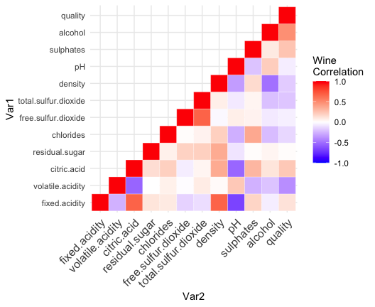

```r
ggplot(melted_cor_wine, aes(Var2, Var1, fill = value))+
 geom_tile(color = "white")+
 scale_fill_gradient2(low = "blue", high = "red", mid = "white",
   midpoint = 0, limit = c(-1,1), space = "Lab",
   name="Wine\nCorrelation") +
  theme_minimal()+
 theme(axis.text.x = element_text(angle = 45, vjust = 1,
    size = 12, hjust = 1))+
 coord_fixed()
```

Box plot of the quality of all of the wines Lowest quality is 3, highest quality is 8. Q1 is 5, the median and Q3 are at 6, the min is 4 and the max is 7 with outliers at 3 and 8. The cutoff for a good wine would be at 6.

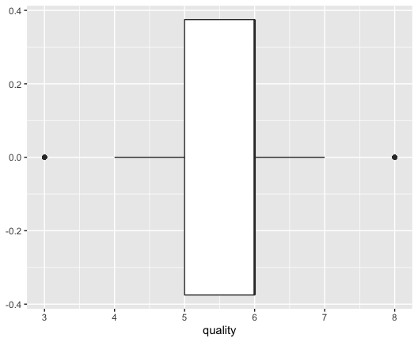

```r
p <- ggplot(wine_clean, aes(x=quality)) +
  geom_boxplot()
p
```

```r
wine_clean <- wine_clean %>%
  mutate(quality = ifelse(quality >= 6 , 1, 0))

wine_clean <- wine_clean %>%
  mutate(quality = factor(quality))

wine_clean
```

|  | fixed.acidity | volatile.acidity | citric.acid | residual.sugar | chlorides | free.sulfur.dioxide | total.sulfur.dioxide | density | pH | sulphates | alcohol | quality |
| --- | --- | --- | --- | --- | --- | --- | --- | --- | --- | --- | --- | --- |
| 1 | 7.4 | 0.700 | 0.00 | 1.90 | 0.076 | 11.0 | 34 | 0.99780 | 3.51 | 0.56 | 9.4 | 0 |
| 2 | 7.8 | 0.880 | 0.00 | 2.60 | 0.098 | 25.0 | 67 | 0.99680 | 3.20 | 0.68 | 9.8 | 0 |
| 3 | 7.8 | 0.760 | 0.04 | 2.30 | 0.092 | 15.0 | 54 | 0.99700 | 3.26 | 0.65 | 9.8 | 0 |
| 4 | 11.2 | 0.280 | 0.56 | 1.90 | 0.075 | 17.0 | 60 | 0.99800 | 3.16 | 0.58 | 9.8 | 1 |
| 5 | 7.4 | 0.700 | 0.00 | 1.90 | 0.076 | 11.0 | 34 | 0.99780 | 3.51 | 0.56 | 9.4 | 0 |
| 6 | 7.4 | 0.660 | 0.00 | 1.80 | 0.075 | 13.0 | 40 | 0.99780 | 3.51 | 0.56 | 9.4 | 0 |
| 7 | 7.9 | 0.600 | 0.06 | 1.60 | 0.069 | 15.0 | 59 | 0.99640 | 3.30 | 0.46 | 9.4 | 0 |
| 8 | 7.3 | 0.650 | 0.00 | 1.20 | 0.065 | 15.0 | 21 | 0.99460 | 3.39 | 0.47 | 10.0 | 1 |
| 9 | 7.8 | 0.580 | 0.02 | 2.00 | 0.073 | 9.0 | 18 | 0.99680 | 3.36 | 0.57 | 9.5 | 1 |
| 10 | 7.5 | 0.500 | 0.36 | 6.10 | 0.071 | 17.0 | 102 | 0.99780 | 3.35 | 0.80 | 10.5 | 0 |

[output cut: 990 more lines]

```r
NA
```

Random Forest Model

```r
wine_rf <- randomForest(quality ~ .,
                       data = wine_clean,
                       type = classification,
                       mtry = 7,
                       na.action = na.roughfix,
                       ntree = 100,
                       importance = TRUE)

print(wine_rf)
```

```
Call:
 randomForest(formula = quality ~ ., data = wine_clean, type = classification,      mtry = 7, ntree = 100, importance = TRUE, na.action = na.roughfix)
               Type of random forest: classification
                     Number of trees: 100
No. of variables tried at each split: 7

        OOB estimate of  error rate: 18.14%
Confusion matrix:
    0   1 class.error
0 600 144   0.1935484
1 146 709   0.1707602
```

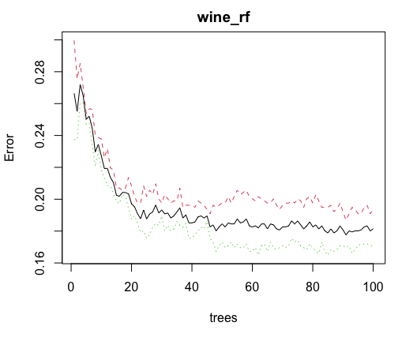

```r
plot(wine_rf)
```

```r
NA
NA
```

```r
wine_rf <- randomForest(quality ~ fixed.acidity + volatile.acidity + citric.acid +
                          chlorides + total.sulfur.dioxide + density + sulphates + alcohol,
                       data = wine_clean,
                       type = classification,
                       mtry = 7,
                       na.action = na.roughfix,
                       ntree = 100,
                       importance = TRUE)

print(wine_rf)
```

```
Call:
 randomForest(formula = quality ~ fixed.acidity + volatile.acidity +      citric.acid + chlorides + total.sulfur.dioxide + density +      sulphates + alcohol, data = wine_clean, type = classification,      mtry = 7, ntree = 100, importance = TRUE, na.action = na.roughfix)
               Type of random forest: classification
                     Number of trees: 100
No. of variables tried at each split: 7

        OOB estimate of  error rate: 17.76%
Confusion matrix:
    0   1 class.error
0 600 144   0.1935484
1 140 715   0.1637427
```

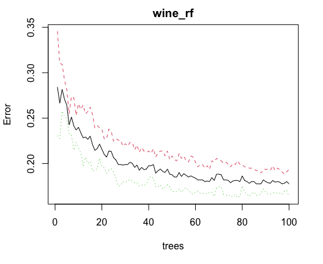

```r
plot(wine_rf)
```

```r
NA
NA
```

Tune the random forest model to determine what the optimal parameters (mtry) are. From the graph we can see that an mtry of 2 would give us the least amount of error

```r
rf_mods <- list()
oob_err <- NULL
test_err <- NULL
for(mtry in 0:11){
  rf_fit <- randomForest(quality ~ fixed.acidity + volatile.acidity + citric.acid +
                          chlorides + total.sulfur.dioxide + density + sulphates + alcohol,
                         data = wine_clean,
                         mtry = mtry,
                         na.action = na.roughfix,
                         ntree = 100)
  oob_err[mtry] <- rf_fit$err.rate[20]

  cat(mtry," ")
}
```

```
0  1  2  3  4  5  6  7  8  9  10  11
```

```r
oob_err
```

```
 [1] 0.2170106 0.1932458 0.1963727 0.2076298 0.2220138 0.1957473 0.2095059 0.1964956 0.2140175
[10] 0.2032520 0.2058824
```

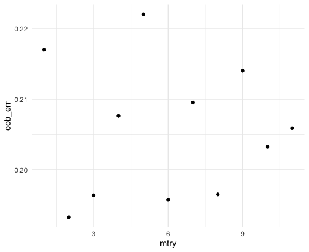

```r
results_DF <- data.frame(mtry = 1:11, oob_err)
ggplot(results_DF, aes(x = mtry, y = oob_err)) + geom_point() + theme_minimal()
```

```r
wine_rf <- randomForest(quality ~ fixed.acidity + volatile.acidity + citric.acid +
                          chlorides + total.sulfur.dioxide + density + sulphates + alcohol,
                       data = wine_clean,
                       type = classification,
                       mtry = 2,
                       na.action = na.roughfix,
                       ntree = 100,
                       importance = TRUE)

print(wine_rf)
```

```
Call:
 randomForest(formula = quality ~ fixed.acidity + volatile.acidity +      citric.acid + chlorides + total.sulfur.dioxide + density +      sulphates + alcohol, data = wine_clean, type = classification,      mtry = 2, ntree = 100, importance = TRUE, na.action = na.roughfix)
               Type of random forest: classification
                     Number of trees: 100
No. of variables tried at each split: 2

        OOB estimate of  error rate: 18.14%
Confusion matrix:
    0   1 class.error
0 593 151   0.2029570
1 139 716   0.1625731
```

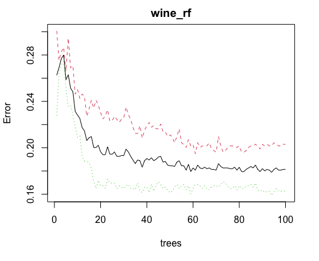

```r
plot(wine_rf)
```

```r
NA
NA
```

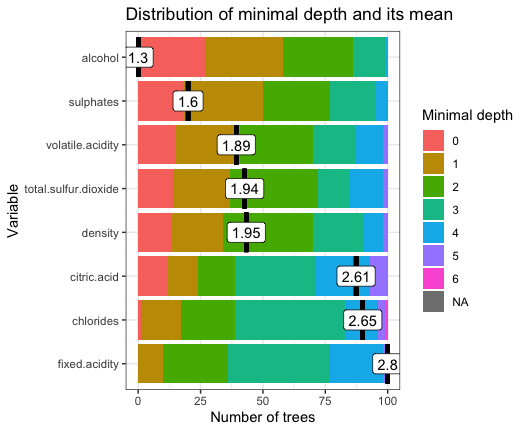

```r
plot_min_depth_distribution(wine_rf)
```

From the importance function we can see that there would be about a 10% decrease in accuracy if alcohol is removed. From this we can conclude that alcohol is an important feature to include.

```r
importance(wine_rf, type = 1, scale = FALSE)
```

```
                     MeanDecreaseAccuracy
fixed.acidity                  0.03524295
volatile.acidity               0.05935481
citric.acid                    0.03761654
chlorides                      0.03399820
total.sulfur.dioxide           0.05702936
density                        0.04799812
sulphates                      0.07372833
alcohol                        0.10817851
```

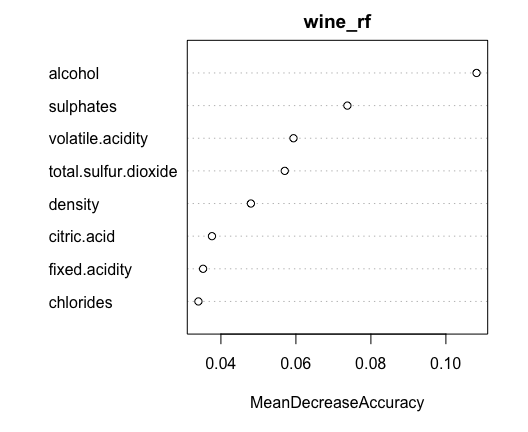

```r
varImpPlot(wine_rf, type = 1, scale = FALSE)
```